# limma_profiles

```python
%pylab inline
import pandas as pd
import numpy as np
import os,re
from time import time
```

```python
def spike(filename):
    pombe = filename[:-8] + 'pombe.sam'
    return sum([1 for i in open(filename) if i[0]!='@'])
```

```python
def limado(filename):
    df = pd.read_csv(filename, index_col=0)
    M = df.loc[-50:250].idxmax()
    v, k = [], []

    for i in M.index:
        m = M.loc[i]
        v.append(df.loc[m-50:m+50, i].sum())
        k.append(i)

    # finally also make the profile to have it handy
    profile = df.mean(axis=1)
    return pd.DataFrame(v, index=k) / spike(filename), profile
```

#### list all experiments of GC, and SM from Mediator and make profiles

```python
for dirFiles in os.listdir('MEDIATOR/'):
    if not re.search('sh$',dirFiles):
        print(dirFiles)
```

```
Med2_15_SM
Med2_15_GC
Med15_GC
Med15_SM
```

not using this for now due to a mislabeling!!

```python
'''p, v,k =[],[],[]
for dirFiles in os.walk('MEDIATOR/Med2_15_GC/'):
    dirs, files = dirFiles[0], dirFiles[1]
    if dirs == 'MEDIATOR/Med2_15_GC/': continue
    checkDir = dirs.split('_')[2].split('/')[1]
    if checkDir not in np.arange(13,25).astype(str): continue
    mtgn = [i for i in os.listdir(dirs) if re.search('.mtgn$',i)]
    if mtgn != []:
        mtgn = mtgn[0]
        name = mtgn[:-11]
        name = 's'+name[:5] + name[14:]
        lima, profile = limado(dirs+'/'+mtgn)
        v.append(lima)
        p.append(profile)
        k.append(name)

Med15_GC = pd.concat(v, axis=1)
Med15_GC.columns = k
# Some columns have only zeros
Med15_GC = Med15_GC.T[Med15_GC.sum(axis=0)>0].T

profiles_Med15_GC = pd.DataFrame(np.vstack(p).T, columns=k, index=np.arange(-1000,1000))
profiles_Med15_GC = profiles_Med15_GC.T[profiles_Med15_GC.sum(axis=0)>0].T''';
```

### Med15_GC

```python
Path = '/fh/scratch/delete30/hahn_s/aerijman/MEDIATOR/Med15_GC/'

c1,c2,c3, t1,t2,t3, c4,c5,c6, t4,t5,t6 = [[Path+j+i for i in os.listdir(Path+j) if re.search("Sc..mtgn$", i)][0]
                                                                      for j in ['13_Sample_225A_Med15_GC_DMSO_A/',
                                                                                '14_Sample_225B_Med15_GC_DMSO_A/',
                                                                                '15_Sample_225C_Med15_GC_DMSO_A/',
                                                                                '16_Sample_226A_Med15_GC_3IAA_A/',
                                                                                '17_Sample_226B_Med15_GC_3IAA_A/',
                                                                                '18_Sample_226C_Med15_GC_3IAA_A/',
                                                                                '19_Sample_227A_Med15_GC_DMSO_B/',
                                                                                '20_Sample_227B_Med15_GC_DMSO_B/',
                                                                                '21_Sample_227C_Med15_GC_DMSO_B/',
                                                                                '22_Sample_228A_Med15_GC_3IAA_B/',
                                                                                '23_Sample_228B_Med15_GC_3IAA_B/',
                                                                                '24_Sample_228C_Med15_GC_3IAA_B/']]

c1,c2,c3,c4,c5,c6,t1,t2,t3,t4,t5,t6, = [limado(i) for i in [c1,c2,c3,c4,c5,c6,t1,t2,t3,t4,t5,t6]]
```

```
Text(0.5,1,'Med15_GC')
```

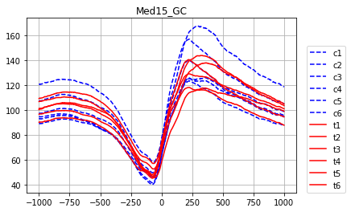

```python
#plt.figure(figsize=(10,10))
cols = ['b']*6 + ['r']*6
ls = ['--']*6 + ['-']*6
[eval(i)[1].plot(label=i, ls=ls[n], c=cols[n]) for n,i in enumerate(['c1','c2','c3','c4','c5','c6','t1','t2','t3','t4','t5','t6'])]
plt.legend(loc=(1.04,0)); plt.grid(); plt.title('Med15_GC')
```

```python
Med15_GC = pd.concat([i[0] for i in [c1,c2,c3,c4,c5,c6,t1,t2,t3,t4,t5,t6]], axis=1)
Med15_GC.columns = ['c1','c2','c3','c4','c5','c6','t1','t2','t3','t4','t5','t6']
Med15_GC.to_csv('med15_gc_limma.csv')
```

### Med15_SM

```python
Path = '/fh/scratch/delete30/hahn_s/aerijman/MEDIATOR/Med15_SM/'

c1,c2,c3, t1,t2,t3, c4,c5,c6, t4,t5,t6 = [[Path+j+i for i in os.listdir(Path+j) if re.search("Sc..mtgn$", i)][0]
                                                                      for j in ['25_Sample_233A_Med15_SM_DMSO_A/',
                                                                                '27_Sample_233B_Med15_SM_DMSO_A/',
                                                                                '29_Sample_233C_Med15_SM_DMSO_A/',
                                                                                '31_Sample_234A_Med15_SM_3IAA_A/',
                                                                                '33_Sample_234B_Med15_SM_3IAA_A/',
                                                                                '35_Sample_234C_Med15_SM_3IAA_A/',
                                                                                '37_Sample_235A_Med15_SM_DMSO_B/',
                                                                                '39_Sample_235B_Med15_SM_DMSO_B/',
                                                                                '41_Sample_235C_Med15_SM_DMSO_B/',
                                                                                '43_Sample_236A_Med15_SM_3IAA_B/',
                                                                                '45_Sample_236B_Med15_SM_3IAA_B/',
                                                                                '47_Sample_236C_Med15_SM_3IAA_B/']]

c1,c2,c3,c4,c5,c6,t1,t2,t3,t4,t5,t6, = [limado(i) for i in [c1,c2,c3,c4,c5,c6,t1,t2,t3,t4,t5,t6]]
```

```
Text(0.5,1,'Med15_SM')
```

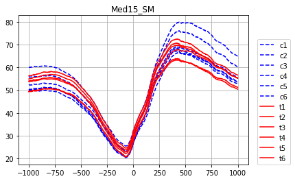

```python
#plt.figure(figsize=(10,10))
cols = ['b']*6 + ['r']*6
ls = ['--']*6 + ['-']*6
[eval(i)[1].plot(label=i, ls=ls[n], c=cols[n]) for n,i in enumerate(['c1','c2','c3','c4','c5','c6','t1','t2','t3','t4','t5','t6'])]
plt.legend(loc=(1.04,0)); plt.grid(); plt.title('Med15_SM')
```

```python
Med15_SM = pd.concat([i[0] for i in [c1,c2,c3,c4,c5,c6,t1,t2,t3,t4,t5,t6]], axis=1)
Med15_SM.columns = ['c1','c2','c3','c4','c5','c6','t1','t2','t3','t4','t5','t6']
Med15_SM.to_csv('med15_sm_limma.csv')
```

### Med2_15_GC

```python
Path = '/fh/scratch/delete30/hahn_s/aerijman/MEDIATOR/Med2_15_GC/'

c1,c2,c3, t1,t2,t3, c4,c5,c6, t4,t5,t6 = [[Path+j+i for i in os.listdir(Path+j) if re.search("Sc..mtgn$", i)][0]
                                                                  for j in ['13_Sample_229A_Med2_15_GC_DMSO_A/',
                                                                            '14_Sample_229B_Med2_15_GC_DMSO_A/',
                                                                            '15_Sample_229C_Med2_15_GC_DMSO_A/',
                                                                            '16_Sample_230A_Med2_15_GC_3IAA_A/',
                                                                            '17_Sample_230B_Med2_15_GC_3IAA_A/',
                                                                            '18_Sample_230C_Med2_15_GC_3IAA_A/',
                                                                            '19_Sample_231A_Med2_15_GC_DMSO_B/',
                                                                            '20_Sample_231B_Med2_15_GC_DMSO_B/',
                                                                            '21_Sample_231C_Med2_15_GC_DMSO_B/',
                                                                            '22_Sample_232A_Med2_15_GC_3IAA_B/',
                                                                            '23_Sample_232B_Med2_15_GC_3IAA_B/',
                                                                            '24_Sample_232C_Med2_15_GC_3IAA_B/']]

c1,c2,c3,c4,c5,c6,t1,t2,t3,t4,t5,t6, = [limado(i) for i in [c1,c2,c3,c4,c5,c6,t1,t2,t3,t4,t5,t6]]
```

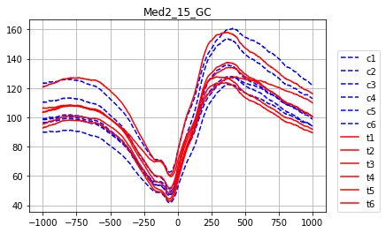

```python
#plt.figure(figsize=(10,10))
cols = ['b']*6 + ['r']*6
ls = ['--']*6 + ['-']*6
[eval(i)[1].plot(label=i, ls=ls[n], c=cols[n]) for n,i in enumerate(['c1','c2','c3','c4','c5','c6',
                                                                     't1','t2','t3','t4','t5','t6'])]
plt.legend(loc=(1.04,0)); plt.grid(); plt.title('Med2_15_GC');
```

```python
Med2_15_GC = pd.concat([i[0] for i in [c1,c2,c3,c4,c5,c6,t1,t2,t3,t4,t5,t6]], axis=1)
Med2_15_GC.columns = ['c1','c2','c3','c4','c5','c6','t1','t2','t3','t4','t5','t6']
Med2_15_GC.to_csv('Med2_15_GC_limma.csv')
```

### Med2_15_SM

```python
Path = '/fh/scratch/delete30/hahn_s/aerijman/MEDIATOR/Med2_15_SM/'

c1,c2,c3, t1,t2,t3, c4,c5,c6, t4,t5,t6 = [[Path+j+i for i in os.listdir(Path+j) if re.search("Sc..mtgn$", i)][0]
                                                                  for j in ['25_Sample_237A_Med2_15_SM_DMSO_A/',
                                                                            '27_Sample_237B_Med2_15_SM_DMSO_A/',
                                                                            '29_Sample_237C_Med2_15_SM_DMSO_A/',
                                                                            '31_Sample_238A_Med2_15_SM_3IAA_A/',
                                                                            '33_Sample_238B_Med2_15_SM_3IAA_A/',
                                                                            '35_Sample_238C_Med2_15_SM_3IAA_A/',
                                                                            '37_Sample_239A_Med2_15_SM_DMSO_B/',
                                                                            '39_Sample_239B_Med2_15_SM_DMSO_B/',
                                                                            '41_Sample_239C_Med2_15_SM_DMSO_B/',
                                                                            '43_Sample_240A_Med2_15_SM_3IAA_B/',
                                                                            '45_Sample_240B_Med2_15_SM_3IAA_B/',
                                                                            '47_Sample_240C_Med2_15_SM_3IAA_B/']]

c1,c2,c3,c4,c5,c6,t1,t2,t3,t4,t5,t6, = [limado(i) for i in [c1,c2,c3,c4,c5,c6,t1,t2,t3,t4,t5,t6]]
```

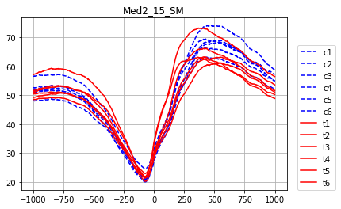

```python
#plt.figure(figsize=(10,10))
cols = ['b']*6 + ['r']*6
ls = ['--']*6 + ['-']*6
[eval(i)[1].plot(label=i, ls=ls[n], c=cols[n]) for n,i in enumerate(['c1','c2','c3','c4','c5','c6',
                                                                     't1','t2','t3','t4','t5','t6'])]
plt.legend(loc=(1.04,0)); plt.grid(); plt.title('Med2_15_SM');
```

```python
Med2_15_SM = pd.concat([i[0] for i in [c1,c2,c3,c4,c5,c6,t1,t2,t3,t4,t5,t6]], axis=1)
Med2_15_SM.columns = ['c1','c2','c3','c4','c5','c6','t1','t2','t3','t4','t5','t6']
Med2_15_SM.to_csv('Med2_15_SM_limma.csv')
```

summarize Med15 and Med2_15 experiments in different combinations

```python
ctrols = ['c1','c2','c3','c4','c5','c6']
treats = ['t1','t2','t3','t4','t5','t6']
columns = ctrols + treats

# Med15
Med15_DMSO = pd.concat([Med15_GC[ctrols], Med15_SM[ctrols]], axis=1)
Med15_3IAA = pd.concat([Med15_GC[treats], Med15_SM[treats]], axis=1)

Med15_DMSO.columns, Med15_3IAA.columns = columns, columns

Med15_DMSO.to_csv('Med15_DMSO_limma.csv')
Med15_3IAA.to_csv('Med15_3IAA_limma.csv')

# Med2_15
Med2_15_DMSO = pd.concat([Med2_15_GC[ctrols], Med2_15_SM[ctrols]], axis=1)
Med2_15_3IAA = pd.concat([Med2_15_GC[treats], Med2_15_SM[treats]], axis=1)

Med2_15_DMSO.columns, Med2_15_3IAA.columns = columns, columns

Med2_15_DMSO.to_csv('Med2_15_DMSO_limma.csv')
Med2_15_3IAA.to_csv('Med2_15_3IAA_limma.csv')
```

### Spt8

```python
Path = '/fh/scratch/delete30/hahn_s/aerijman/SAGA/spt8/'

dmso1, dmso2, _3iaa1, _3iaa2 = [[Path+j+i for i in os.listdir(Path+j)
                                 if re.search("Sc..mtgn$", i)][0] for j in ['1_Sample_161_Spt8_deg_YPD_DMSO_A/',
                                                                            '3_Sample_163_Spt8_deg_YPD_DMSO_B/',
                                                                            '2_Sample_162_Spt8_deg_YPD_3IAA_A/',
                                                                            '4_Sample_164_Spt8_deg_YPD_3IAA_B/']]

c1, c2, t1, t2 = [limado(i) for i in [dmso1, dmso2, _3iaa1, _3iaa2]]
```

```
Text(0.5,1,'Spt8')
```

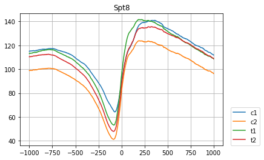

```python
#plt.figure(figsize=(10,10))
[eval(i)[1].plot(label=i) for i in ['c1','c2','t1','t2']]
plt.legend(loc=(1.04,0)); plt.grid(); plt.title('Spt8')
```

```python
spt8 = pd.concat([c1[0],c2[0],t1[0],t2[0]], axis=1)
spt8.columns = ['c1','c2','t1','t2']
spt8.to_csv('spt8_limma.csv')
```

### Spt7_3

```python
Path = '/fh/scratch/delete30/hahn_s/aerijman/SAGA/spt7_3/'

c1,c2,c3, t1,t2,t3, c4,c5,c6, t4,t5,t6 = [[Path+j+i for i in os.listdir(Path+j) if re.search("Sc..mtgn$", i)][0]
                                                                      for j in ['10_Sample_252A_Spt7_3_YPD_DMSO_B/',
                                                                                '11_Sample_252B_Spt7_3_YPD_DMSO_B/',
                                                                                '12_Sample_252C_Spt7_3_YPD_DMSO_B/',
                                                                                '1_Sample_249A_Spt7_3_YPD_3IAA_A/',
                                                                                '2_Sample_249B_Spt7_3_YPD_3IAA_A/',
                                                                                '3_Sample_249C_Spt7_3_YPD_3IAA_A/',
                                                                                '4_Sample_250A_Spt7_3_YPD_DMSO_A/',
                                                                                '5_Sample_250B_Spt7_3_YPD_DMSO_A/',
                                                                                '6_Sample_250C_Spt7_3_YPD_DMSO_A/',
                                                                                '7_Sample_251A_Spt7_3_YPD_3IAA_B/',
                                                                                '8_Sample_251B_Spt7_3_YPD_3IAA_B/',
                                                                                '9_Sample_251C_Spt7_3_YPD_3IAA_B/']]

c1,c2,c3,c4,c5,c6,t1,t2,t3,t4,t5,t6 = [limado(i) for i in [c1,c2,c3,c4,c5,c6,t1,t2,t3,t4,t5,t6]]
```

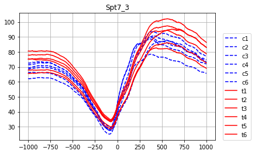

```python
#plt.figure(figsize=(10,10))
cols = ['b']*6 + ['r']*6
ls = ['--']*6 + ['-']*6
[eval(i)[1].plot(label=i, c=cols[n], ls=ls[n]) for n,i in enumerate(['c'+str(i) for i in np.arange(1,7)] + ['t'+str(i) for i in np.arange(1,7)])]
plt.legend(loc=(1.04,0)); plt.grid(); plt.title('Spt7_3');
```

```python
spt7_3 = pd.concat([i[0] for i in [c1,c2,c3,c4,c5,c6,t1,t2,t3,t4,t5,t6]], axis=1)
spt7_3.columns = np.sort([t+str(i) for i in np.arange(1,7) for t in ['c','t']])
spt7_3.to_csv('spt7_3_limma.csv')
```

## Spt20

```python
Path = '/fh/scratch/delete30/hahn_s/aerijman/SAGA/spt20/'

t1,c1,t2,c2,t3,t4,c3 = [[Path+j+i for i in os.listdir(Path+j) if re.search("Sc..mtgn$", i)][0] for j in
                                                                           ['10_Sample_144_Spt20_deg_YPD_3IAA_B/',
                                                                            '15_Sample_221_Spt20_deg_YPD_DMSO_A/',
                                                                            '16_Sample_222_Spt20_deg_YPD_3IAA_A/',
                                                                            '17_Sample_223_Spt20_deg_YPD_DMSO_B/',
                                                                            '18_Sample_224_Spt20_deg_YPD_3IAA_B/',
                                                                            '8_Sample_142_Spt20_deg_YPD_3IAA_A/',
                                                                            '9_Sample_143_Spt20_deg_YPD_DMSO_B/']]

c1gc,t1gc,c2gc,t2gc = [[Path+j+i for i in os.listdir(Path+j) if re.search("Sc..mtgn$", i)][0] for j in ['11_Sample_145_Spt20_deg_GC_DMSO_A/',
                                                                                                        '12_Sample_146_Spt20_deg_GC_3IAA_A/',
                                                                                                        '13_Sample_147_Spt20_deg_GC_DMSO_B/',
                                                                                                        '14_Sample_148_Spt20_deg_GC_3IAA_B/',]]


c1,c2,c3,t1,t2,t3,t4, c1gc,c2gc,t1gc,t2gc = [limado(i) for i in [c1,c2,c3,t1,t2,t3,t4, c1gc,c2gc,t1gc,t2gc]]
```

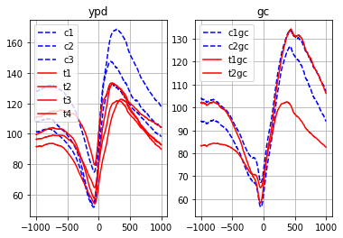

```python
#plt.figure(figsize=(18,10)); plt.suptitle('Spt20')
plt.subplot(121); plt.title('ypd')
cols = ['b']*3 + ['r']*4
ls = ['--']*3 + ['-']*4
[eval(i)[1].plot(label=i, c=cols[n], ls=ls[n]) for n,i in enumerate(['c'+str(i) for i in np.arange(1,4)] + ['t'+str(i) for i in np.arange(1,5)])]
plt.legend(); plt.grid()

plt.subplot(122); plt.title('gc')
cols = ['b']*2 + ['r']*2
ls = ['--']*2 + ['-']*2
[eval(i)[1].plot(label=i, c=cols[n], ls=ls[n]) for n,i in enumerate(['c1gc','c2gc','t1gc','t2gc'])]
plt.legend(); plt.grid();
```

```python
spt20ypd= pd.concat([i[0] for i in [c1,c2,c3,t1,t2,t3,t4]], axis=1)
spt20ypd.columns = ['c1','c2','c3','t1','t2','t3','t4']
spt20ypd.to_csv('spt20ypd_limma.csv')

spt20gc= pd.concat([i[0] for i in [c1gc,c2gc,t1gc,t2gc]], axis=1)
spt20gc.columns = ['c1','c2','t1','t2']
spt20gc.to_csv('spt20gc_limma.csv')
```

## Spt8_3

```python
Path = '/fh/scratch/delete30/hahn_s/aerijman/SAGA/spt_8_3/'

c1,t1,t2,t3,c2,c3,c4,c5,t4,c6,t5,t6,t7,t8,c7,c8 = [[Path+j+i for i in os.listdir(Path+j) if re.search("Sc..mtgn$", i)][0] for j in
                                                                                                   ['10_Sample_254C_Spt8_3_YPD_DMSO_A/',
                                                                                                    '11_Sample_255A_Spt8_3_YPD_3IAA_B/',
                                                                                                    '12_Sample_255B_Spt8_3_YPD_3IAA_B/',
                                                                                                    '13_Sample_255C_Spt8_3_YPD_3IAA_B/',
                                                                                                    '14_Sample_256A_Spt8_3_YPD_DMSO_B/',
                                                                                                    '15_Sample_256B_Spt8_3_YPD_DMSO_B/',
                                                                                                    '16_Sample_256C_Spt8_3_YPD_DMSO_B/',
                                                                                                    '1_Sample_217_Spt3_Spt8_deg_YPD_DMSO_A/',
                                                                                                    '2_Sample_218_Spt3_Spt8_deg_YPD_3IAA_A/',
                                                                                                    '3_Sample_219_Spt3_Spt8_deg_YPD_DMSO_B/',
                                                                                                    '4_Sample_220_Spt3_Spt8_deg_YPD_3IAA_B/',
                                                                                                    '5_Sample_253A_Spt8_3_YPD_3IAA_A/',
                                                                                                    '6_Sample_253B_Spt8_3_YPD_3IAA_A/',
                                                                                                    '7_Sample_253C_Spt8_3_YPD_3IAA_A/',
                                                                                                    '8_Sample_254A_Spt8_3_YPD_DMSO_A/',
                                                                                                    '9_Sample_254B_Spt8_3_YPD_DMSO_A/']]

c1,c2,c3,c4,c5,c6,c7,c8,t1,t2,t3,t4,t5,t6,t7,t8 = [limado(i) for i in [c1,c2,c3,c4,c5,c6,c7,c8,t1,t2,t3,t4,t5,t6,t7,t8]]
```

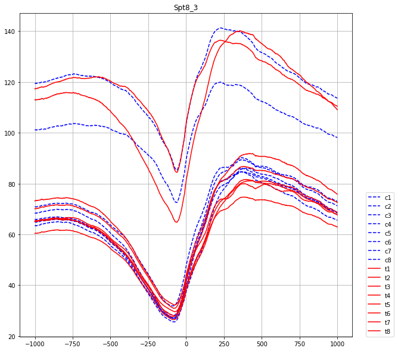

```python
#plt.figure(figsize=(10,10))
cols = ['b']*8 + ['r']*8
ls = ['--']*8 + ['-']*8
[eval(i)[1].plot(label=i, c=cols[n], ls=ls[n]) for n,i in enumerate(['c'+str(i) for i in np.arange(1,9)] + ['t'+str(i) for i in np.arange(1,9)])]
plt.legend(loc=(1.04,0)); plt.grid(); plt.title('Spt8_3');
```

test for batch effect!

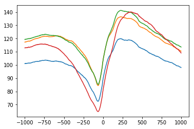

```python
[i[1].plot() for i in [c5,t4,c6,t5]];
```

Indeed...

```python
spt8_3 = pd.concat([i[0] for i in [c1,c2,c3,c4,c5,c6,c7,c8,t1,t2,t3,t4,t5,t6,t7,t8]], axis=1)
spt8_3.columns = ['c'+str(i) for i in np.arange(1,9)] + ['t'+str(i) for i in np.arange(1,9)]
spt8_3.to_csv('spt8_3_limma.csv')
```

## Spt20_3

```python
Path = '/fh/scratch/delete30/hahn_s/aerijman/SAGA/spt20_3/'

c1,c2,c3, t1,t2,t3, c4,c5,c6, t4,t5,t6 = [[Path+j+i for i in os.listdir(Path+j) if re.search("Sc..mtgn$", i)][0] for j in
                                                                                       ['10_Sample_248A_Spt20_3_YPD_DMSO_B/',
                                                                                        '11_Sample_248B_Spt20_3_YPD_DMSO_B/',
                                                                                        '12_Sample_248C_Spt20_3_YPD_DMSO_B/',
                                                                                        '1_Sample_245A_Spt20_3_YPD_3IAA_A/',
                                                                                        '2_Sample_245B_Spt20_3_YPD_3IAA_A/',
                                                                                        '3_Sample_245C_Spt20_3_YPD_3IAA_A/',
                                                                                        '4_Sample_246A_Spt20_3_YPD_DMSO_A/',
                                                                                        '5_Sample_246B_Spt20_3_YPD_DMSO_A/',
                                                                                        '6_Sample_246C_Spt20_3_YPD_DMSO_A/',
                                                                                        '7_Sample_247A_Spt20_3_YPD_3IAA_B/',
                                                                                        '8_Sample_247B_Spt20_3_YPD_3IAA_B/',
                                                                                        '9_Sample_247C_Spt20_3_YPD_3IAA_B/']]

c1,c2,c3,c4,c5,c6,t1,t2,t3,t4,t5,t6, = [limado(i) for i in [c1,c2,c3,c4,c5,c6,t1,t2,t3,t4,t5,t6]]
```

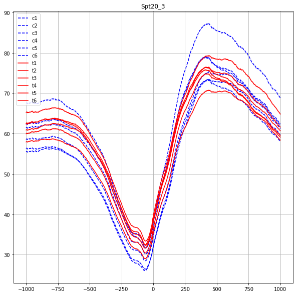

```python
#plt.figure(figsize=(10,10))
cols = ['b']*6 + ['r']*6
ls = ['--']*6 + ['-']*6
[eval(i)[1].plot(label=i, c=cols[n], ls=ls[n]) for n,i in enumerate(['c'+str(i) for i in np.arange(1,7)] + ['t'+str(i) for i in np.arange(1,7)])]
plt.legend(loc='upper left'); plt.grid(); plt.title('Spt20_3');
```

```python
spt20_3 = pd.concat([i[0] for i in [c1,c2,c3,c4,c5,c6,t1,t2,t3,t4,t5,t6]], axis=1)
spt20_3.columns = ['c'+str(i) for i in np.arange(1,7)] + ['t'+str(i) for i in np.arange(1,7)]
spt20_3.to_csv('spt20_3_limma.csv')
```

## Spt20_7

```python
Path = '/fh/scratch/delete30/hahn_s/aerijman/SAGA/spt20_7/'

c1,c2,c3, t1,t2,t3, c4,c5,c6, t4,t5,t6 = [[Path+j+i for i in os.listdir(Path+j) if re.search("Sc..mtgn$", i)][0] for j in
                                                                                       ['10_Sample_244A_Spt20_7_YPD_DMSO_B/',
                                                                                        '11_Sample_244B_Spt20_7_YPD_DMSO_B/',
                                                                                        '12_Sample_244C_Spt20_7_YPD_DMSO_B/',
                                                                                        '1_Sample_241A_Spt20_7_YPD_3IAA_A/',
                                                                                        '2_Sample_241B_Spt20_7_YPD_3IAA_A/',
                                                                                        '3_Sample_241C_Spt20_7_YPD_3IAA_A/',
                                                                                        '4_Sample_242A_Spt20_7_YPD_DMSO_A/',
                                                                                        '5_Sample_242B_Spt20_7_YPD_DMSO_A/',
                                                                                        '6_Sample_242C_Spt20_7_YPD_DMSO_A/',
                                                                                        '7_Sample_243A_Spt20_7_YPD_3IAA_B/',
                                                                                        '8_Sample_243B_Spt20_7_YPD_3IAA_B/',
                                                                                        '9_Sample_243C_Spt20_7_YPD_3IAA_B/']]

c1,c2,c3,c4,c5,c6,t1,t2,t3,t4,t5,t6, = [limado(i) for i in [c1,c2,c3,c4,c5,c6,t1,t2,t3,t4,t5,t6]]
```

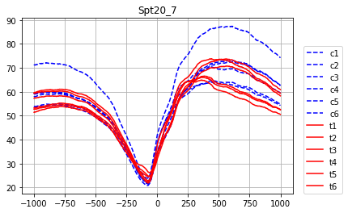

```python
#plt.figure(figsize=(10,10))
cols = ['b']*6 + ['r']*6
ls = ['--']*6 + ['-']*6
[eval(i)[1].plot(label=i, c=cols[n], ls=ls[n]) for n,i in enumerate(['c'+str(i) for i in np.arange(1,7)] + ['t'+str(i) for i in np.arange(1,7)])]
plt.legend(loc=(1.04,0)); plt.grid(); plt.title('Spt20_7');
```

```python
spt20_7 = pd.concat([i[0] for i in [c1,c2,c3,c4,c5,c6,t1,t2,t3,t4,t5,t6]], axis=1)
spt20_7.columns = ['c'+str(i) for i in np.arange(1,7)] + ['t'+str(i) for i in np.arange(1,7)]
spt20_7.to_csv('spt20_7_limma.csv')
```

Steve suggested not using the samples that were processed on 17/11/20 in Spt8_3 data

```python
Path = '/fh/scratch/delete30/hahn_s/aerijman/SAGA/spt_8_3/'

c1,t1,t2,t3,c2,c3,c4,t4,t5,t6,c5,c6 = [[Path+j+i for i in os.listdir(Path+j)
                                                    if re.search("Sc..mtgn$", i)][0] for j in [
                                                    '10_Sample_254C_Spt8_3_YPD_DMSO_A/',
                                                    '11_Sample_255A_Spt8_3_YPD_3IAA_B/',
                                                    '12_Sample_255B_Spt8_3_YPD_3IAA_B/',
                                                    '13_Sample_255C_Spt8_3_YPD_3IAA_B/',
                                                    '14_Sample_256A_Spt8_3_YPD_DMSO_B/',
                                                    '15_Sample_256B_Spt8_3_YPD_DMSO_B/',
                                                    '16_Sample_256C_Spt8_3_YPD_DMSO_B/',
                                                    '5_Sample_253A_Spt8_3_YPD_3IAA_A/',
                                                    '6_Sample_253B_Spt8_3_YPD_3IAA_A/',
                                                    '7_Sample_253C_Spt8_3_YPD_3IAA_A/',
                                                    '8_Sample_254A_Spt8_3_YPD_DMSO_A/',
                                                    '9_Sample_254B_Spt8_3_YPD_DMSO_A/']]

c1,c2,c3,c4,c5,c6,t1,t2,t3,t4,t5,t6 = [limado(i) for i in [c1,c2,c3,c4,c5,c6,t1,t2,t3,t4,t5,t6]]
```

```python
spt8_3b = pd.concat([i[0] for i in [c1,c2,c3,c4,c5,c6,t1,t2,t3,t4,t5,t6]], axis=1)
spt8_3b.columns = ['c'+str(i) for i in np.arange(1,7)] + ['t'+str(i) for i in np.arange(1,7)]
spt8_3b.to_csv('spt8_3b_limma.csv')
```

### Which genes are affected by Med15 upon addition of SM?

[figure not shown]

```python
_3iaa = pd.read_csv('./data/volcanoMed15_3IAA.csv', index_col=0)
_dmso = pd.read_csv('./data/volcanoMed15_DMSO.csv', index_col=0)
```

```python
_3iaa.columns
```

```
Index(['logFC', 'AveExpr', 't', 'P.Value', 'adj.P.Val', 'B'], dtype='object')
```

```python
def positives(df): return (set(df[(df['logFC']>np.log(1.5)) & (df['adj.P.Val']<=0.05)].index))
def negatives(df): return (set(df[(df['logFC']<-np.log(1.5)) & (df['adj.P.Val']<=0.05)].index))

pt = positives(_3iaa)
pc = positives(_dmso)
nt = negatives(_3iaa)
nc = negatives(_dmso)
```

Do Linda's old Gal11 deletion qPCR experiments correlate well with her new Pol-II-ChIP?

```python
genes = {
    'ARG3':'YJL088W',
    'HIS4':'YCL030C',
    'ARG1':'YOL058W',
    'STR3':'YGL184C',
    'ARG5':'YER069W',
    'ALD5':'YER073W',
    'PCL5':'YHR071W',
    'ILV6':'YCL009C',
    'SNO1':'YMR095C'
}

k,v = [],[]
columns = ['posit/DMSO', 'negat/DMSO', 'posit/3IAA', 'negat/3IAA']
for name,locus in genes.items():
    k.append(name)
    v.append([locus in i for i in [pc, nc, pt, nt]])

df = pd.DataFrame(v, index=k, columns=columns)
```

```python
for i in os.listdir('./figures/'):
    print(i)
```

```
spt8_3b_limma_volcano.jpg
med15_gc_limma_volcano.jpg
med15_sm_limma_volcano.jpg
spt20_7_limma_volcano.jpg
spt7_3_limma_volcano.jpg
spt20ypd_limma_volcano.jpg
Med2_15_3IAA_limma_volcano.jpg
Med15_3IAA_limma_volcano.jpg
spt8_3_limma_volcano.jpg
Med2_15_GC_limma_volcano.jpg
spt20_3_limma_volcano.jpg
Med15_DMSO_limma_volcano.jpg
spt20gc_limma_volcano.jpg
spt8_3b_limma.jpg
spt8_limma_volcano.jpg
Med2_15_SM_limma_volcano.jpg
Med2_15_DMSO_limma_volcano.jpg
```

### Do Pugh's definitions fit out experimental data?

```python
pugh = pd.read_csv('mmc2.csv', header=1, skiprows=[2,3], index_col=1)
pugh_sets = list(set(pugh.iloc[:,0]))
pugh_sets
```

```
[nan, 'TFIID-dominated', 'SAGA-dominated', 'no call', 'SAGA/TFIID']
```

Where are SAGA and TFIID dependent (Pugh definition) in the volcano of Spt samples.

```python
titles = ['data/volcanospt20_3.csv', 'data/volcanospt20gc.csv', 'data/volcanospt8_3b.csv']
df = pd.read_csv(titles[0], index_col=0)
df2 = pd.read_csv(titles[1], index_col=0)
df3 = pd.read_csv(titles[2], index_col=0)
```

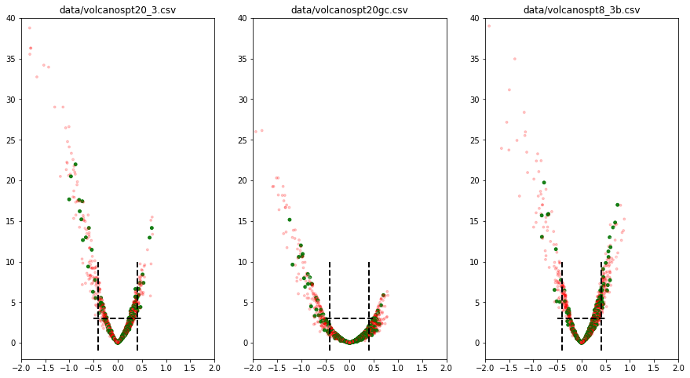

```python
def limits():
    plt.xlim(-2,2)
    plt.ylim(-2,40)

cols, size = [], []
for i in pugh.index:
    if pugh.loc[i,pugh.columns[0]]==pugh_sets[2]:
        cols.append([0,0.45,0,0.9]); size.append(15)
    elif pugh.loc[i,pugh.columns[0]]==pugh_sets[1]:
        cols.append([1,0,0, 0.2]); size.append(8)
    else:
        cols.append([1,1,1,0.2]); size.append(8)

plt.figure(figsize=(15,8))
plt.subplot(131)
plt.scatter(df.logFC, -np.log(df['adj.P.Val']), c=cols, s=size); plt.title(titles[0])
plt.plot([-0.5,0.5], [-np.log(0.05)]*2, lw=2, ls='--', c='k')
plt.plot([-np.log(1.5)]*2, [-1,10], lw=2, ls='--', c='k')
plt.plot([np.log(1.5)]*2, [-1,10], lw=2, ls='--', c='k')
limits()

plt.subplot(132)
plt.scatter(df2.logFC, -np.log(df2['adj.P.Val']), c=cols, s=size); plt.title(titles[1])
plt.plot([-0.5,0.5], [-np.log(0.05)]*2, lw=2, ls='--', c='k')
plt.plot([-np.log(1.5)]*2, [-1,10], lw=2, ls='--', c='k')
plt.plot([np.log(1.5)]*2, [-1,10], lw=2, ls='--', c='k')
limits()

plt.subplot(133)
plt.scatter(df3.logFC, -np.log(df3['adj.P.Val']), c=cols, s=size); plt.title(titles[2])
plt.plot([-0.5,0.5], [-np.log(0.05)]*2, lw=2, ls='--', c='k')
plt.plot([-np.log(1.5)]*2, [-1,10], lw=2, ls='--', c='k')
plt.plot([np.log(1.5)]*2, [-1,10], lw=2, ls='--', c='k')
limits()
```

No difference between SAGA and TFIID

```python
#spts = [i for i in os.listdir('./data/') if re.search('volcanospt', i)]
spts = [
 'volcanospt8_3.csv',
 'volcanospt20_3.csv',
 'volcanospt20_7.csv',
 'volcanospt8_3b.csv'
]

df = pd.concat([pd.read_csv('./data/'+i, index_col=0)['logFC'] for i in spts], axis=1, sort=True)
df.columns = [i[10:-4] for i in spts]

z = lambda x: (x-np.mean(x)) / np.std(x)
# After having applied voom it's not necessary to z-score them... Nevertheless, it won't hurt
df = z(df)
```

```python
spts
```

```
['volcanospt8_3.csv',
 'volcanospt20_3.csv',
 'volcanospt20_7.csv',
 'volcanospt8_3b.csv']
```

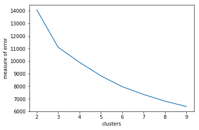

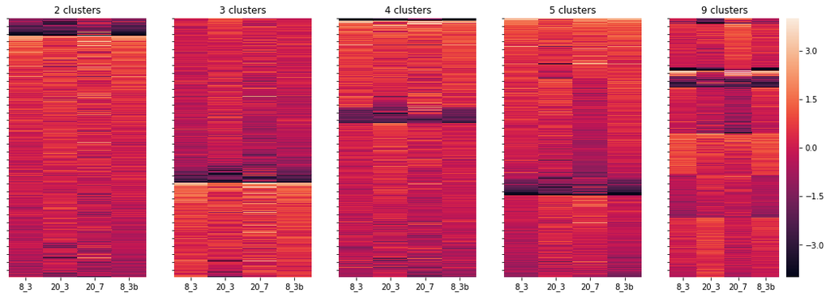

```python
from sklearn.cluster import KMeans
import seaborn as sns

inertias=[]
for k in range(2,10):
    km = KMeans(n_clusters=k, random_state=42, n_init=20, max_iter=600).fit(df.values)
    inertias.append(km.inertia_)

plt.figure()
plt.plot(np.arange(2,10), inertias)
plt.xlabel('clusters'); plt.ylabel('measure of error')

plt.figure(figsize=(18,6))
for n,k in enumerate([2,3,4,5,9]):
    km = KMeans(n_clusters=k, random_state=42, n_init=20, max_iter=600).fit_predict(df.values)
    tmp = df.copy()
    tmp['label'] = km
    tmp['av'] = tmp[df.columns].mean(axis=1)
    tmp = tmp.sort_values(['label','av'], ascending=False).drop(['label', 'av'], axis=1)
    plt.subplot(1,5,n+1)
    cbar = [False if k<9 else True][0]
    ax = sns.heatmap(tmp, cbar=cbar, vmin=-4, vmax=4); plt.title(str(k)+ ' clusters')
    ax.set_yticklabels([])
```

```
array([[<matplotlib.axes._subplots.AxesSubplot object at 0x7f92193b6d30>,
      dtype=object)
```

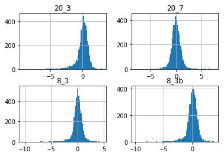

```python
df.hist(bins=100)
```

```
[0.62894008 0.20334742]
```

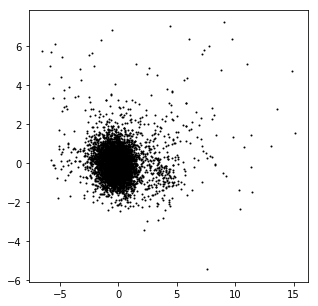

```python
tmp = df.copy()
km = KMeans(n_clusters=2, n_init=20, max_iter=600).fit_predict(tmp)
tmp['label'] = km
#l0=tmp[tmp.label==0].index
#l1=tmp[tmp.label==1].index

from sklearn.decomposition import PCA

plt.figure(figsize=(5,5))
pca = PCA(n_components=2).fit(df.values)
print(pca.explained_variance_ratio_)
pca = PCA(n_components=2).fit_transform(df.values)
plt.scatter(pca[:,0], pca[:,1], s=1, c='k')

df_pca = pd.DataFrame(pca, index=df.index)
df_pca = pd.concat([df_pca, tmp.label], axis=1, sort=True)
```

```
356
```

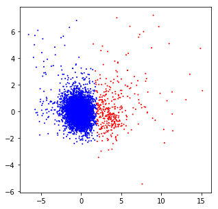

```python
cols = ['b' if i==0 else 'r' for i in df_pca.label.values]
plt.figure(figsize=(5,5))
plt.scatter(df_pca[0].values, df_pca[1].values, c=cols, s=1)
np.sum(np.array(cols)=='r')
```

```python
'''for i in df_pca[df_pca.label==1].index:
    print(i)''';

# These are of course, ribosomal proteins...
```

The two groups obtained with kmeans and pca are the same!!

1. Are these the highly expressed genes?
2. Do they correlate with Pugh?
3. Do they correlate with ChEC of SAGA?

```python
import seaborn as sns
idx = tmp[tmp.label==1].index
gc_sm = pd.read_csv('./data/Med15_DMSO_limma.csv', index_col=0)
gc_sm = gc_sm[['c1','c2','c3','c4','c5','c6']].mean(axis=1)
gc_sm = gc_sm.sort_values(ascending=False)
```

```
[Text(0,0,'cluster0'), Text(0,0,'cluster1')]
```

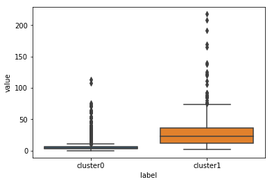

```python
a = pd.concat([gc_sm, tmp.label], axis=1, sort=True)
a['label'] = a.label.fillna(0).astype(int)
a.columns = ['value','label']
ax = sns.boxplot(data=a, y='value', x='label')
ax.set_xticklabels(['cluster0', 'cluster1'])
```

**1** The group with the least number of genes has higher signal in DMSO, it might be composed of the most highly expressed genes.

```python
set(pugh.iloc[:,0])
```

```
{'SAGA-dominated', 'SAGA/TFIID', 'TFIID-dominated', nan, 'no call'}
```

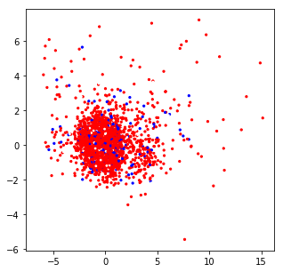

```python
cols_pugh, sp = [], []
n=0
for i in pugh.iloc[:,0].values:
    if i== 'SAGA-dominated':
        cols_pugh.append('b'); sp.append(5)
    elif i=='TFIID-dominated':
        n+=1; cols_pugh.append('r'); sp.append(5)
    else:
        cols_pugh.append('w'); sp.append(3)
plt.figure(figsize=(5,5))
plt.scatter(df_pca[0].values, df_pca[1].values, c=cols_pugh, s=sp)
```

**2** Our clustering doesn't agree with Pugh!

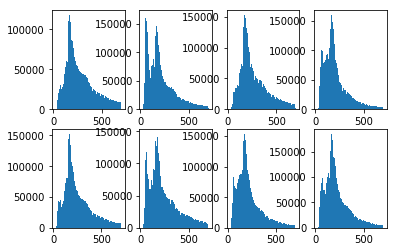

```python
files = [
    '1_Sample_25A_Spt3_YPD_25_noCMK_A/',
    '2_Sample_25B_Spt3_YPD_5_noCMK_A/',
    '3_Sample_25C_Spt3_YPD_25_CMK_A/',
    '4_Sample_25D_Spt3_YPD_5_CMK_A/',
    '5_Sample_26A_Spt3_YPD_25_noCMK_B/',
    '6_Sample_26B_Spt3_YPD_5_noCMK_B/',
    '7_Sample_26C_Spt3_YPD_25_CMK_B/',
    '8_Sample_26D_Spt3_YPD_5_CMK_B/'
]
filenames = [['ChEC/spt3/'+j+i for i in os.listdir('ChEC/spt3/'+j) if re.search("Sc.sam", i)] for j in files]
hists, bins = [], []
for n,filename in enumerate(filenames):
    sam = [i for i in open(filename[0]) if i[0] !='@']
    lengths = np.array([i.split('\t')[8] for i in sam], float)
    lengths = lengths[lengths>=0]
    #hist, bin_edges = np.histogram(lengths, bins=np.linspace(0,1000,100))
    #hists.append(hist)
    #bins.append(bin_edges)
    plt.subplot(2,4,n+1)
    plt.hist(lengths, bins=100)
```

```python
roman_numbers = ['0','I','II','III','IV','V','VI','VII','VIII','IX','X','XI','XII','XIII','XIV','XV','XVI']
# SGD info
TSS = pd.read_excel('/home/aerijman/aerijman/.scripts/supp_gkt1366_nar-02868-n-2013-File009.xls', index_col=2)
TSS.iloc[:,0] = [roman_numbers.index(i.strip('chr')) for i in TSS.iloc[:,0]]
SGD = pd.read_csv('/home/aerijman/aerijman/.scripts/SGD_features.tab', delimiter='\t', header=None)
SGD = SGD[SGD.iloc[:,1] == 'ORF']
SGD = SGD.iloc[:,[3,8,9,10,11]]
SGD.columns = ['id','chromosome','left','right','strand']
SGD.set_index('id', inplace=True)
SGD['strand'] = [1 if i=='W' else -1 for i in SGD['strand']]
SGD = pd.concat([SGD, TSS.coordinate], axis=1, sort=True)
SGD = SGD[SGD.chromosome!='2-micron']
SGD = SGD.dropna().astype(int)
```

```python
spt3_peaks = pd.read_csv('./ChEC/spt3/5_Sample_26A_Spt3_YPD_25_noCMK_B/Spt3_5.bed', delimiter='\t', header=None)
romans = ['0','I','II','III','IV','V','VI','VII','VIII','IX','X','XI','XII','XIII','XIV','XV','XVI']
spt3_peaks['chrom'] = [romans.index(i.strip('chr')) for i in spt3_peaks.iloc[:,0]]
spt3_peaks = spt3_peaks.iloc[:,1:]
spt3_peaks.columns = ['left','right','center','chrom']

columns = ['chromosome','start','end','-','int(-10*log10qvalue)','.','log_change','-log(p_value)','-log(q_value)','summit?']
spt3_macs = pd.read_csv('./ChEC/spt3/5_Sample_26A_Spt3_YPD_25_noCMK_B/NA_peaks.narrowPeak', delimiter='\t', header=None, index_col=3, names=columns)
```

```python
spt3_macs[spt3_macs.iloc[:,5]>=2]
spt3_macs['chromosome'] = [romans.index(i) for i in spt3_macs['chromosome']]


SGD['downstream'] = SGD.coordinate + 50 * SGD.strand
SGD['upstream'] = SGD.coordinate - 400 * SGD.strand
SGD['M'] = SGD[['downstream','upstream']].max(axis=1)
SGD['m'] = SGD[['downstream', 'upstream']].min(axis=1)

def assign_peak(chromosome, start, summit):
    peak = start + summit
    potential = SGD[(SGD.chromosome==chromosome) & (peak >= SGD.m) & (peak <= SGD.M)]
    return(list(potential.index))

peaks = []
for i in spt3_macs.index:
    chromosome, start, end = spt3_macs.loc[i,['chromosome','start','summit?']]
    peaks.append(assign_peak(chromosome, start, end))

peaks = list(set(np.hstack(peaks)))
```

```
356
```

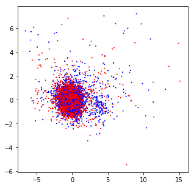

```python
df_pca['colors'] = 'r'
df_pca.loc[peaks, 'colors'] = 'b'
plt.figure(figsize=(5,5))
plt.scatter(df_pca[0].values, df_pca[1].values, c=df_pca['colors'].values, s=1)
np.sum(np.array(cols)=='r')
```

**3** Peaks of SAGA belong to both groups. This is being very conservative with q_values of 0.01, I could try with:  
4. using Homer results  
5. 0.005 and fold_change>2

```python
#print(df_pca[(df_pca.label==1) & (df_pca.colors=='b')].shape)

red_small = 122/(3349+122)*100.0
blue_small = 243/(1500+234)*100.0

red_big = 3349 / (3349+122)*100.0
blue_big = 1500 / (1500+234)*100.0

print('not called genes {:.1f}% and called genes {:.1f}% in small group'.format(red_small, blue_small))
print('not called genes {:.1f}% and called genes {:.1f}% in big group'.format(red_big, blue_big))
```

```
not called genes 3.5% and called genes 14.0% in small group
not called genes 96.5% and called genes 86.5% in big group
```

```python
spt3_homer = pd.read_csv('./ChEC/spt3/5_Sample_26A_Spt3_YPD_25_noCMK_B/Spt3_5.bed', delimiter='\t', names = ['chromosome','start','end','summit'])
spt3_homer['chromosome'] = [romans.index(i.strip('chr')) for i in spt3_homer.chromosome]

def assign_peak(chromosome, peak):
    potential = SGD[(SGD.chromosome==chromosome) & (peak >= SGD.m) & (peak <= SGD.M)]
    return(list(potential.index))

peaks = []
for i in spt3_homer.index:
    chromosome, summit = spt3_homer.loc[i,['chromosome','summit']]
    peaks.append(assign_peak(chromosome, summit))

peaks = list(set(np.hstack(peaks)))
```

```
356
```

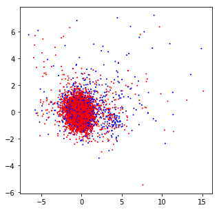

```python
df_pca['colors'] = 'r'
df_pca.loc[peaks, 'colors'] = 'b'
plt.figure(figsize=(5,5))
plt.scatter(df_pca[0].values, df_pca[1].values, c=df_pca['colors'].values, s=1)
np.sum(np.array(cols)=='r')
```

```python
print(df_pca[(df_pca.label==1) & (df_pca.colors=='r')].shape)

red_small = 195/(858+195)*100.0
blue_small = 161/(3991+161)*100.0

red_big = 858 / (858+195)*100.0
blue_big = 3991 / (3991+161)*100.0

print('not called genes {:.1f}% and called genes {:.1f}% in small group'.format(red_small, blue_small))
print('not called genes {:.1f}% and called genes {:.1f}% in big group'.format(red_big, blue_big))
```

```
(161, 4)
not called genes 18.5% and called genes 3.9% in small group
not called genes 81.5% and called genes 96.1% in big group
```

```
356
```

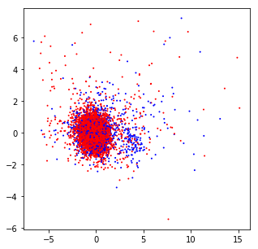

```python
spt3_peaks = pd.read_csv('./ChEC/spt3/5_Sample_26A_Spt3_YPD_25_noCMK_B/Spt3_5.bed', delimiter='\t', header=None)
romans = ['0','I','II','III','IV','V','VI','VII','VIII','IX','X','XI','XII','XIII','XIV','XV','XVI']
spt3_peaks['chrom'] = [romans.index(i.strip('chr')) for i in spt3_peaks.iloc[:,0]]
spt3_peaks = spt3_peaks.iloc[:,1:]
spt3_peaks.columns = ['left','right','center','chrom']

columns = ['chromosome','start','end','-','int(-10*log10qvalue)','.','log_change','-log(p_value)','-log(q_value)','summit?']
spt3_macs = pd.read_csv('./ChEC/spt3/5_Sample_26A_Spt3_YPD_25_noCMK_B/NA_peaks.narrowPeak', delimiter='\t', header=None, index_col=3, names=columns)
spt3_macs[spt3_macs.iloc[:,5]>=2]
spt3_macs['chromosome'] = [romans.index(i) for i in spt3_macs['chromosome']]

spt3_macs = spt3_macs[spt3_macs['log_change']>3]

def assign_peak(chromosome, start, summit):
    peak = start + summit
    potential = SGD[(SGD.chromosome==chromosome) & (peak >= SGD.m) & (peak <= SGD.M)]
    return(list(potential.index))

peaks = []
for i in spt3_macs.index:
    chromosome, start, end = spt3_macs.loc[i,['chromosome','start','summit?']]
    peaks.append(assign_peak(chromosome, start, end))

peaks = list(set(np.hstack(peaks)))

df_pca['colors'] = 'r'
df_pca.loc[peaks, 'colors'] = 'b'
plt.figure(figsize=(5,5))
plt.scatter(df_pca[0].values, df_pca[1].values, c=df_pca['colors'].values, s=1)
np.sum(np.array(cols)=='r')
```

```python
print(df_pca[(df_pca.label==1) & (df_pca.colors=='b')].shape)

red_small = 158/(3951+158)*100.0
blue_small = 198/(898+198)*100.0

red_big = 3851 / (3951+158)*100.0
blue_big = 898 / (898+198)*100.0

print('not called genes {:.1f}% and called genes {:.1f}% in small group'.format(red_small, blue_small))
print('not called genes {:.1f}% and called genes {:.1f}% in big group'.format(red_big, blue_big))
```

```
(198, 4)
not called genes 3.8% and called genes 18.1% in small group
not called genes 93.7% and called genes 81.9% in big group
```

**Conclussions**:

The small group of genes that are highly expressed are the genes with highest decrease in transcriiption upon degradation of two SAGA proteins in a double-degron experiment. This group has nothing to be with the SAGA/TFIID deffinition of Pugh.

```
356
```

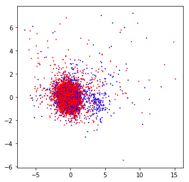

```python
spt3_peaks = pd.read_csv('./ChEC/spt3/5_Sample_26A_Spt3_YPD_25_noCMK_B/Spt3_5.bed', delimiter='\t', header=None)
romans = ['0','I','II','III','IV','V','VI','VII','VIII','IX','X','XI','XII','XIII','XIV','XV','XVI']
spt3_peaks['chrom'] = [romans.index(i.strip('chr')) for i in spt3_peaks.iloc[:,0]]
spt3_peaks = spt3_peaks.iloc[:,1:]
spt3_peaks.columns = ['left','right','center','chrom']

columns = ['chromosome','start','end','-','int(-10*log10qvalue)','.','log_change','-log(p_value)','-log(q_value)','summit?']
spt3_macs = pd.read_csv('./ChEC/spt3/6_Sample_26B_Spt3_YPD_5_noCMK_B/q005_peaks.narrowPeak', delimiter='\t', header=None, index_col=3, names=columns)
spt3_macs[spt3_macs.iloc[:,5]>=2]
spt3_macs['chromosome'] = [romans.index(i) for i in spt3_macs['chromosome']]

spt3_macs = spt3_macs[spt3_macs['log_change']>3]

def assign_peak(chromosome, start, summit):
    peak = start + summit
    potential = SGD[(SGD.chromosome==chromosome) & (peak >= SGD.m) & (peak <= SGD.M)]
    return(list(potential.index))

peaks = []
for i in spt3_macs.index:
    chromosome, start, end = spt3_macs.loc[i,['chromosome','start','summit?']]
    peaks.append(assign_peak(chromosome, start, end))

peaks = list(set(np.hstack(peaks)))

df_pca['colors'] = 'r'
df_pca.loc[peaks, 'colors'] = 'b'
plt.figure(figsize=(5,5))
plt.scatter(df_pca[0].values, df_pca[1].values, c=df_pca['colors'].values, s=1)
np.sum(np.array(cols)=='r')
```

```python
print(df_pca[(df_pca.label==1) & (df_pca.colors=='r')].shape)

red_small = 143/(3869+143)*100.0
blue_small = 213/(980+213)*100.0

red_big = 3869 / (3869+243)*100.0
blue_big = 980 / (980+2113)*100.0

print('not called genes {:.1f}% and called genes {:.1f}% in small group'.format(red_small, blue_small))
print('not called genes {:.1f}% and called genes {:.1f}% in big group'.format(red_big, blue_big))
```

[output not shown]

```python
!ls ./chromatin/*bw | sort
```

```
./chromatin/GSM1849277_H3K4me3-H3.WT.R1.bw
./chromatin/GSM1849278_H3K4me3-H3.WT.R2.bw
./chromatin/GSM1849279_H3K4me3-H3.H4K44R.R1.bw
./chromatin/GSM1849280_H3K4me3-H3.H4K44R.R2.bw
./chromatin/GSM1849281_H3K56ac-H3.WT.R1.bw
./chromatin/GSM1849282_H3K56ac-H3.WT.R2.bw
./chromatin/GSM1849283_H3K56ac-H3.H4K44R.R1.bw
./chromatin/GSM1849284_H3K56ac-H3.H4K44R.R2.bw
./chromatin/GSM1849289_Rad51-Input.WT.R1.bw
./chromatin/GSM1849290_Rad51-Input.WT.R2.bw
./chromatin/GSM1849291_Rad51-Input.H4K44R.R1.bw
./chromatin/GSM1849292_Rad51-Input.H4K44R.R2.bw
```